# Mediation Analysis

Daniela Cossio

10 June 2025

# Reading in and prepping our data

Here we are reading in the following folders and paths

- Path to the main dir with all the data “/Users/danielacossio/Documents/Chrastil_Lab/Projects/SNAG/DSI_rerun_data/DSP/”
- Path to the subject sheet that contains every single subject who has useable behavior. “/Users/danielacossio/Documents/Chrastil_Lab/Projects/SNAG/sub_info_sheets/SNAG_DSP_scans.csv”
- Path to the subject sheet that has the list of subjects that have both a DSP score AND a DSI scan.

Complete Subject Database

```r
TableOutput(All_sub_info)
```

| subject_id | viq | education_years | ethnicity | subject_id2 | completed_scan | completed_spatial | sex | age_group | age_scan_years | age_spatial_years | repo_status | loop_useable | loop_pe_rad1_m | loop_pe_rad2_m | loop_pe_rad3_m | loop_pe_avg_m | loop_de_rad1_degree | loop_de_rad2_degree | loop_de_rad3_degree | loop_de_avg_degree | loop_ae_rad1_degree | loop_ae_rad2_degree | loop_ae_rad3_degree | loop_ae_avg_degree | maze_useable | maze_accuracy_pct | maze_moves | maze_path_efficiency | dsp_useable | … |
| --- | --- | --- | --- | --- | --- | --- | --- | --- | --- | --- | --- | --- | --- | --- | --- | --- | --- | --- | --- | --- | --- | --- | --- | --- | --- | --- | --- | --- | --- | --- |
| 301 | 127 | 14 | White | MaMo | Yes | Yes | Female | Midlife | 60 | 61 | Post | No | NA | NA | NA | NA | NA | NA | NA | NA | NA | NA | NA | NA | Yes | 0.1250000 | 259 | 0.9634304 | Yes | … |
| 306 | 129 | 16 | White | LoCa | Yes | Yes | Female | Midlife | 57 | 58 | Post | No | NA | NA | NA | NA | NA | NA | NA | NA | NA | NA | NA | NA | Yes | 0.0000000 | 210 | 0.9248871 | Yes | … |
| 307 | 121 | 16 | White | RuSh | Yes | Yes | Female | Midlife | 59 | 61 | Post | Yes | 0.9836755 | 1.8193954 | 3.932784 | 2.2452848 | 313.3554 | 323.3426 | 294.0538 | 310.2506 | 62.62922 | 61.61895 | 96.48074 | 73.57630 | No | NA | NA | NA | No | … |
| 310 | 121 | 16 | White | CaCo | Yes | Yes | Female | Midlife | 49 | 48 | Pre | Yes | 0.7476238 | 1.3322496 | 2.031944 | 1.3706058 | 405.7968 | 385.4284 | 398.3151 | 396.5134 | 45.49690 | 39.26530 | 40.24428 | 41.66883 | Yes | 0.0000000 | 269 | 1.2428126 | Yes | … |
| 311 | 132 | 18 | White | LaBr | Yes | Yes | Female | Midlife | 50 | 50 | Peri | Yes | 0.4981031 | 0.7249980 | 1.873749 | 1.0322834 | 364.1125 | 355.6011 | 359.9472 | 359.8869 | 22.90614 | 20.94550 | 39.87317 | 27.90827 | No | NA | NA | NA | Yes | … |
| 312 | 124 | 14 | White | SaCh | Yes | Yes | Female | Midlife | 47 | 48 | Peri | Yes | 0.7967668 | 0.9726604 | 1.746382 | 1.1719363 | 309.3184 | 354.0514 | 334.5010 | 332.6236 | 51.55217 | 28.75111 | 35.15389 | 38.48573 | Yes | 0.0833333 | 266 | 1.0156723 | Yes | … |
| 313 | 123 | 14 | White | MoMo | Yes | Yes | Female | Midlife | 53 | 54 | Peri | Yes | NA | 0.8913090 | 1.985067 | 1.4381877 | NA | 333.7168 | 367.3711 | 350.5439 | NA | 26.74614 | 41.84633 | 34.29623 | Yes | 0.2083333 | 288 | 1.1927481 | Yes | … |
| 315 | 131 | 14 | White | SaWh | Yes | Yes | Female | Midlife | 43 | 44 | Pre | Yes | 0.5478470 | 1.6987110 | 3.720657 | 1.9890716 | 362.7810 | 402.7768 | 484.9566 | 416.8381 | 31.00134 | 51.50171 | 86.85854 | 56.45386 | Yes | 0.1250000 | 299 | 1.0988845 | Yes | … |
| 318 | 128 | 18 | White | LySw | Yes | Yes | Female | Midlife | 49 | 49 | Pre | No | NA | NA | NA | NA | NA | NA | NA | NA | NA | NA | NA | NA | No | NA | NA | NA | Yes | … |
| 319 | 120 | 18 | Mexican | DaBa | Yes | Yes | Male | Midlife | 60 | 61 | Men | Yes | 0.4958176 | 1.5180956 | 2.652217 | 1.5553768 | 331.6282 | 362.6155 | 348.5492 | 347.5976 | 28.47725 | 51.13473 | 61.13704 | 46.91634 | Yes | 0.0416667 | 266 | 1.2552974 | Yes | … |
| 320 | 124 | 16 | White | DaPa | No | Yes | Male | Midlife | 44 | 45 | Men | Yes | 0.7541761 | 1.4852211 | 3.947293 | 2.0622302 | 409.7284 | 407.5659 | 443.8042 | 420.3662 | 46.52903 | 47.47190 | 89.90028 | 61.30040 | Yes | 0.6250000 | 273 | 1.0267054 | Yes | … |
| 321 | 115 | 16 | White | BrKe | Yes | Yes | Male | Midlife | 50 | 51 | Men | Yes | NA | 1.2301180 | NA | 1.2301180 | NA | 344.9175 | NA | 344.9175 | NA | 37.27760 | NA | 37.27760 | Yes | 0.1250000 | 315 | 1.2196746 | Yes | … |
| 322 | 130 | 18 | White | PaLa | Yes | Yes | Male | Midlife | 48 | 48 | Men | Yes | 1.1152296 | 2.1293245 | 3.740011 | 2.3281883 | 379.3040 | 343.4222 | 274.6959 | 332.4740 | 69.97343 | 68.12536 | 87.66755 | 75.25545 | Yes | 0.0833333 | 269 | 0.9836611 | Yes | … |
| 323 | 128 | 16 | White | LiFe | Yes | Yes | Female | Midlife | 48 | 48 | Pre | Yes | 0.6059356 | 0.8319840 | 2.293995 | 1.2439716 | 336.0155 | 344.2219 | 343.1046 | 341.1140 | 38.18530 | 24.28591 | 45.98484 | 36.15202 | Yes | 0.2916667 | 274 | 1.0234175 | Yes | … |
| 324 | 121 | 14 | Native American/Alaskan | JeEs | Yes | Yes | Female | Midlife | 48 | 48 | Pre | Yes | 1.3980198 | 2.9505164 | 4.288506 | 2.8790142 | 257.0545 | 265.3444 | 252.0855 | 258.1615 | 103.14161 | 117.97106 | 102.98967 | 108.03411 | Yes | 0.0416667 | 288 | 1.3943966 | Yes | … |
| 325 | 130 | 18 | White | DaGo | Partial | Yes | Male | Midlife | 48 | 48 | Men | Yes | 0.7393697 | 1.6734009 | 2.579680 | 1.6641501 | 314.0980 | 310.1010 | 299.2514 | 307.8168 | 44.88673 | 58.33234 | 55.53626 | 52.91844 | Yes | 1.0000000 | 275 | 1.0167519 | No | … |
| 326 | 123 | 16 | White | SaEb | Yes | Yes | Female | Midlife | 51 | 50 | Post | Yes | 1.0117940 | 1.3635968 | 3.020074 | 1.7984882 | 293.2148 | 317.5985 | 297.8405 | 302.8846 | 67.20177 | 42.75879 | 63.81035 | 57.92364 | Yes | 0.0416667 | 275 | 1.2375786 | No | … |
| 327 | 128 | 20 | White | LiFr | Yes | Yes | Female | Midlife | 52 | 52 | Post | Yes | 0.5298612 | 1.0840454 | 2.602889 | 1.4055984 | 333.2024 | 349.5035 | 356.5190 | 346.4083 | 30.27165 | 32.39933 | 52.82201 | 38.49767 | Yes | 0.0416667 | 264 | 1.2085479 | Yes | … |
| 328 | 112 | 16 | Mexican | HeAc | No | Yes | Male | Midlife | 53 | 53 | Men | Yes | 0.7434053 | 0.8382221 | 1.402596 | 0.9947413 | 336.3818 | 345.0094 | 337.5615 | 339.6509 | 45.43473 | 24.63808 | 26.81562 | 32.29614 | No | NA | NA | NA | No | … |
| 330 | 128 | 20 | White | JeSc | Yes | Yes | Male | Midlife | 54 | 54 | Men | Yes | 0.4150408 | 1.0616022 | 1.796771 | 1.0911380 | 358.9958 | 329.0835 | 351.9290 | 346.6694 | 24.51538 | 30.94980 | 35.88812 | 30.45110 | Yes | 0.3750000 | 263 | 1.0825976 | Yes | … |
| 332 | 128 | 14 | White | SiBy | Yes | Yes | Female | Midlife | 52 | 52 | Peri | No | NA | NA | NA | NA | NA | NA | NA | NA | NA | NA | NA | NA | Yes | 0.0833333 | 248 | 1.1385747 | No | … |
| 333 | 129 | 16 | Mixed | JeHe | Yes | Yes | Female | Midlife | 45 | 45 | Pre | Yes | 1.7746410 | 3.1525542 | 4.365634 | 3.0976096 | 197.5003 | 244.8585 | 257.9559 | 233.4383 | 154.48974 | 115.42732 | 102.20615 | 124.04107 | Yes | 0.2083333 | 285 | 1.2125022 | No | … |
| 334 | 131 | 16 | White | JuLa | Yes | Yes | Female | Midlife | 53 | 53 | Post | Yes | 0.3514592 | 2.8572464 | 3.736760 | 2.3151552 | 353.9169 | 463.1049 | 440.1707 | 419.0642 | 18.01619 | 94.29213 | 79.87125 | 64.05985 | Yes | 0.1250000 | 218 | 0.9499700 | No | … |
| 335 | 130 | 20 | Mixed | DiAr | No | Yes | Female | Midlife | 48 | 49 | Post | Yes | 0.6614268 | 2.2464519 | 3.905248 | 2.2710423 | 483.5965 | 445.0380 | 403.0532 | 443.8959 | 39.86732 | 78.62382 | 92.29758 | 70.26291 | No | NA | NA | NA | No | … |
| 336 | 123 | 16 | White | ReAs | No | Yes | Female | Midlife | 55 | 55 | Post | No | NA | NA | NA | NA | NA | NA | NA | NA | NA | NA | NA | NA | Yes | 0.1666667 | 232 | 1.0896459 | No | … |
| 337 | 131 | 18 | White | LoGo | Yes | Yes | Female | Midlife | 53 | 53 | Peri | Yes | 0.4394984 | 1.9785889 | 4.014735 | 2.1442740 | 361.6340 | 423.7157 | 458.1412 | 414.4970 | 20.79653 | 63.37353 | 97.62998 | 60.60001 | Yes | 0.0000000 | 202 | 1.0355566 | No | … |
| 338 | 131 | 16 | White | KaGa | No | Yes | Female | Midlife | 54 | 54 | Post | Yes | 0.8507759 | 1.7584761 | 2.577602 | 1.7289514 | 324.1460 | 308.0804 | 310.4295 | 314.2186 | 49.69657 | 52.06763 | 51.72838 | 51.16419 | Yes | 0.0000000 | 212 | 1.2007875 | No | … |
| 339 | 125 | 14 | White | LiCr | Yes | Yes | Female | Midlife | 43 | 43 | Pre | Yes | 0.6597003 | 2.6762509 | NA | 1.6679756 | 387.6562 | 543.2058 | NA | 465.4310 | 40.17764 | 105.03366 | NA | 72.60565 | Yes | 0.0417000 | 262 | 1.0121010 | No | … |
| 340 | 125 | 16 | White | LiRi | Yes | Yes | Female | Midlife | 50 | 50 | Pre | Yes | 0.5508640 | 1.0903902 | 3.303211 | 1.6481549 | 353.7580 | 356.9961 | 374.2601 | 361.6714 | 32.66132 | 32.54088 | 69.40254 | 44.86825 | Yes | 0.0000000 | 218 | 0.9899696 | No | … |
| 341 | 117 | 16 | White | ToPa | Partial | Yes | Male | Midlife | 58 | 58 | Men | Yes | 0.8205628 | 0.9845899 | 1.718605 | 1.1745859 | 306.0549 | 362.0423 | 359.5276 | 342.5416 | 54.87042 | 30.15294 | 34.85868 | 39.96068 | No | NA | NA | NA | No | … |

[output cut: 105 more lines]

# Methods and approach

## Thought process

I am doing a mediation analysis to understand the relation ship between white matter, hormones, and performance on the dual solution paradigm.

From shuying’s data, DSP is associated with estradial. Increased solution index is associated with increased solution index.

MD is negatively associated with Solution Index such that increased MD in the fornix is associated with less shortcuts. Essentially lower white matter integrity in fornix is associated with lower performance.

Hypothesis for mediation is that greater estradiol is driving the relationship in which greater integrity in the fornix for greater solution index.

X= Mean diffusivity in fornix  
Y= greater SI on DSP task  
M= Estradiol

## Subject Numbers for DSP analyses

Shuyings numbers are as follows:  
Women: 47  
MEn:29  
Total:76

Daniela’s

Women: 47  
Men: 27  
Total: 74

These are the subject I excluded but she included:  
352  
372  
388

These were excluded later from hippocampal analyses so i just exlcuded their behavior here as well. Adding these in gives me 77 which is still not the correct number of subjects. I’m not sure which one is the extra. For now I’ll add them back in but it shouldn’t affect much.

## Data Cleaning and organizing

### Step 1: Read in the raw data

This is going through and reading in the output from dsi studio and then combining it into one dataframe and then combining that with our data frame that contains our subject data.

```r
# This is a data frame which cotains a folder for each subject with 2 text files
path2data <- ("/Users/danielacossio/Documents/Chrastil_Lab/Projects/SNAG/DSI/Tractometry/output")

# List of all subject directories
subfiles <- list.dirs("/Users/danielacossio/Documents/Chrastil_Lab/Projects/SNAG/DSI/Tractometry/output", full.names = FALSE,recursive = FALSE) # all of the data extracted from dsi

# create an empty dataframe to loop into
fornix_output_df <-  data.frame(matrix(ncol = 5, nrow = 0)) %>% `colnames<-`(c("subjects","QA_L_fornix","QA_R_fornix","MD_L_fornix","MD_R_fornix"))

# creating a loop to go into each sub dir. read in each txt file and extract the
for(file in 1:length((subfiles))){


  # creating an empty single row dataframe
  empty_loop_df <- data.frame(matrix(ncol = 5, nrow = 1))  %>% `colnames<-`(c("subjects","QA_L_fornix","QA_R_fornix","MD_L_fornix","MD_R_fornix"))

  # inputting the subject id
  empty_loop_df$subjects <- str_remove(subfiles[file],"sub-")


  # Let's do a quick folder check to make sure it's not empty


  if(file.size(paste0(path2data,"/",subfiles[file])) < 128) next

  #grabbing all the left and right variables
  L_fornix <- read_delim(paste0(path2data,"/",subfiles[file],"/",subfiles[file],"_space-T1w_desc-preproc_dwi.ProjectionBasalGanglia_FornixL.stat.txt"),col_names = FALSE) %>% filter(X1 %in% c("qa","md"))

  R_fornix <- read_delim(paste0(path2data,"/",subfiles[file],"/",subfiles[file],"_space-T1w_desc-preproc_dwi.ProjectionBasalGanglia_FornixR.stat.txt"),col_names = FALSE) %>% filter(X1 %in% c("qa","md"))

  # Putting them into out dataframe
  #Grab all QA values
  empty_loop_df$QA_L_fornix <- L_fornix$X2[1] # row 1 is QA
  empty_loop_df$QA_R_fornix <- R_fornix$X2[1]


  empty_loop_df$MD_L_fornix <- L_fornix$X2[2] # row 2 is MD
  empty_loop_df$MD_R_fornix <- R_fornix$X2[2]

  fornix_output_df <- rbind(fornix_output_df,empty_loop_df)
}


# now we have to grab the information from sub info and combine but we need to make sure we're grabbing all the correct subjects from each dataframe. Something to note is that this final fornix data frame is based off of scans and includes some people who do not have a DSP score. There's probably a way to simplify the code below.

altered_sub_info <- DSP_DSI_DF %>% filter(subject_id %in% c(fornix_output_df$subjects))

fornix_output_df <- fornix_output_df %>%  filter(subjects %in% c(DSP_DSI_DF$subject_id))


clean_DF <- cbind(altered_sub_info,fornix_output_df)

clean_DF$QA_Whole_Fornix <- rowMeans(clean_DF[,c("QA_L_fornix","QA_R_fornix")])

clean_DF$MD_Whole_Fornix <- rowMeans(clean_DF[,c("MD_L_fornix","MD_R_fornix")])
```

### Step 2: Normality check and visualization of data

#### DSP distribution & Normality (behav only)

Here I am plotting the data for all dsp(regardless of scan). There are a total of 74 subjects here. Shuying had about 76 subjects and i noted the discrpenacy above. You can see there is a right hand skew on this data and it does not pass normality test (p-value = 9.242e-05)

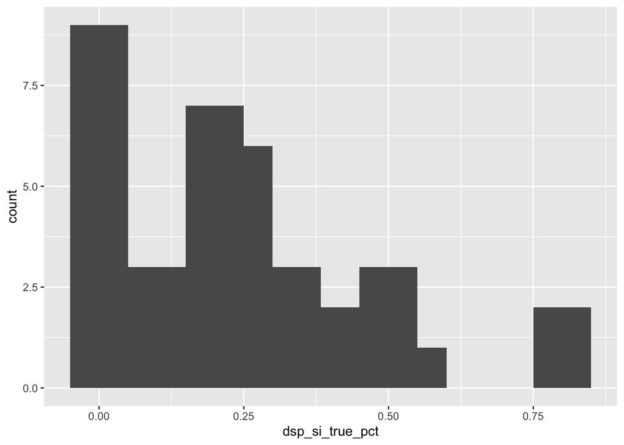

```r
data_dsp <- All_sub_info %>% filter(dsp_useable == "Yes") %>% filter(subject_id < 500) # dataframe with all subjects that have usable DSP

ggplot(data_dsp, aes(x=dsp_si_true_pct)) +
   geom_bar(width = 0.1)
```

```r
shapiro.test(data_dsp$dsp_si_true_pct)
```

```
##
##  Shapiro-Wilk normality test
##
## data:  data_dsp$dsp_si_true_pct
## W = 0.91381, p-value = 9.242e-05
```

The table below summarizes all of the columns. Each row indicates a column location.

```r
TableOutput(describe(data_dsp))
```

| vars | n | mean | sd | median | trimmed | mad | min | max | range | skew | kurtosis | se |
| --- | --- | --- | --- | --- | --- | --- | --- | --- | --- | --- | --- | --- |
| 1 | 74 | 376.5675676 | 41.0836371 | 376.5000000 | 377.8000000 | 51.8910000 | 301.0000000 | 437.0000000 | 136.0000000 | -0.2163180 | -1.2956914 | 4.7758758 |
| 2 | 74 | 125.6891892 | 6.2129464 | 128.0000000 | 126.6000000 | 4.4478000 | 95.0000000 | 132.0000000 | 37.0000000 | -2.1372264 | 6.6843225 | 0.7222404 |
| 3 | 74 | 17.1351351 | 1.8750293 | 17.0000000 | 17.1666667 | 1.4826000 | 14.0000000 | 20.0000000 | 6.0000000 | 0.0528286 | -0.9534405 | 0.2179677 |
| 4 | 74 | 4.7567568 | 0.8409194 | 5.0000000 | 4.9833333 | 0.0000000 | 1.0000000 | 6.0000000 | 5.0000000 | -3.2102597 | 10.1868774 | 0.0977549 |
| 5 | 74 | 37.2297297 | 21.1637758 | 37.5000000 | 37.2833333 | 26.6868000 | 1.0000000 | 73.0000000 | 72.0000000 | -0.0251220 | -1.2495719 | 2.4602390 |
| 6 | 74 | 1.9459459 | 0.2276679 | 2.0000000 | 2.0000000 | 0.0000000 | 1.0000000 | 2.0000000 | 1.0000000 | -3.8645740 | 13.1126761 | 0.0264659 |
| 7 | 74 | 1.0000000 | 0.0000000 | 1.0000000 | 1.0000000 | 0.0000000 | 1.0000000 | 1.0000000 | 0.0000000 | NaN | NaN | 0.0000000 |
| 8 | 74 | 1.3648649 | 0.4846782 | 1.0000000 | 1.3333333 | 0.0000000 | 1.0000000 | 2.0000000 | 1.0000000 | 0.5500927 | -1.7200972 | 0.0563427 |
| 9 | 74 | 1.0000000 | 0.0000000 | 1.0000000 | 1.0000000 | 0.0000000 | 1.0000000 | 1.0000000 | 0.0000000 | NaN | NaN | 0.0000000 |
| 10 | 74 | 50.3108108 | 3.7523533 | 50.0000000 | 50.2000000 | 4.4478000 | 43.0000000 | 60.0000000 | 17.0000000 | 0.3111179 | -0.2978331 | 0.4362022 |
| 11 | 74 | 50.4054054 | 3.8138857 | 50.0000000 | 50.2333333 | 4.4478000 | 44.0000000 | 61.0000000 | 17.0000000 | 0.4822282 | -0.0096871 | 0.4433552 |
| 12 | 74 | 2.3243243 | 1.2175442 | 2.0000000 | 2.2833333 | 1.4826000 | 1.0000000 | 4.0000000 | 3.0000000 | 0.2259914 | -1.5504357 | 0.1415366 |
| 13 | 74 | 1.9459459 | 0.9636104 | 2.0000000 | 1.9333333 | 1.4826000 | 1.0000000 | 3.0000000 | 2.0000000 | 0.1057763 | -1.9291115 | 0.1120174 |
| 14 | 30 | 0.6851550 | 0.2552038 | 0.6197664 | 0.6575965 | 0.1944186 | 0.3529723 | 1.3980198 | 1.0450475 | 0.9224793 | 0.1909860 | 0.0465936 |
| 15 | 32 | 1.5854509 | 0.7166789 | 1.4087354 | 1.4906716 | 0.6351272 | 0.7249980 | 3.3575483 | 2.6325504 | 0.9501712 | 0.0535957 | 0.1266921 |
| 16 | 29 | 2.9275364 | 0.9013364 | 2.7981405 | 2.8748274 | 0.7969141 | 1.6633586 | 5.3296238 | 3.6662652 | 0.6397061 | -0.2340955 | 0.1673740 |
| 17 | 32 | 1.6867830 | 0.5819947 | 1.5562138 | 1.6300279 | 0.6010341 | 0.7152435 | 3.2152239 | 2.4999804 | 0.8075435 | -0.0199642 | 0.1028831 |
| 18 | 30 | 351.3679825 | 41.8098643 | 356.7290971 | 352.6352834 | 37.5193609 | 257.0545313 | 425.0970950 | 168.0425637 | -0.1987979 | -0.4033183 | 7.6334019 |
| 19 | 32 | 367.8476949 | 57.4621733 | 351.7774412 | 362.8876420 | 38.4129168 | 265.3444172 | 518.0729118 | 252.7284946 | 0.8347166 | 0.6391107 | 10.1579731 |
| 20 | 29 | 374.3382678 | 81.6575330 | 351.9289524 | 368.8306569 | 67.0975023 | 252.0855158 | 558.1561749 | 306.0706591 | 0.8023150 | -0.3543618 | 15.1634232 |
| 21 | 32 | 363.9063378 | 53.1412887 | 347.1335071 | 361.5180136 | 45.9956880 | 258.1614881 | 488.3051734 | 230.1436853 | 0.4625484 | -0.1993726 | 9.3941414 |
| 22 | 30 | 44.6497996 | 21.9910322 | 39.7606911 | 41.5773975 | 17.1054374 | 19.1913707 | 103.1416095 | 83.9502388 | 1.0575206 | 0.3486001 | 4.0149948 |
| 23 | 32 | 52.2248270 | 29.0316704 | 43.3686016 | 47.6071539 | 21.4123252 | 20.9455022 | 128.1522211 | 107.2067189 | 1.1639562 | 0.4922250 | 5.1321227 |
| 24 | 29 | 65.7996441 | 25.0097193 | 59.0530058 | 64.0514584 | 25.5106170 | 32.9872587 | 135.7723902 | 102.7851315 | 0.7482624 | -0.0486716 | 4.6441883 |
| 25 | 32 | 53.1079385 | 22.8800061 | 45.9642966 | 49.7258175 | 16.2969828 | 27.9082729 | 109.6747831 | 81.7665102 | 1.1353825 | 0.3052777 | 4.0446519 |
| 26 | 74 | 1.8108108 | 0.3943323 | 2.0000000 | 1.8833333 | 0.0000000 | 1.0000000 | 2.0000000 | 1.0000000 | -1.5550877 | 0.4245809 | 0.0458402 |
| 27 | 60 | 0.1597178 | 0.1937895 | 0.1250000 | 0.1232597 | 0.1235006 | 0.0000000 | 1.0000000 | 1.0000000 | 2.9071181 | 9.4843646 | 0.0250181 |
| 28 | 60 | 265.8666667 | 35.7702019 | 270.5000000 | 268.5833333 | 28.9107000 | 185.0000000 | 345.0000000 | 160.0000000 | -0.5835370 | -0.1382291 | 4.6179132 |
| 29 | 60 | 1.0928732 | 0.1571817 | 1.0588675 | 1.0824247 | 0.1478859 | 0.8362463 | 1.4906232 | 0.6543769 | 0.6319165 | -0.0770258 | 0.0202921 |
| 30 | 74 | 1.0000000 | 0.0000000 | 1.0000000 | 1.0000000 | 0.0000000 | 1.0000000 | 1.0000000 | 0.0000000 | NaN | NaN | 0.0000000 |

[output cut: 62 more lines]

So can we then try and normalize the data?

Here let’s normalize using log transform. Log transform does change the skew but also some numbers (0) are now labeled as inf. Meaning we should do something to make those turn into an acutal number perhaps 0.0001?

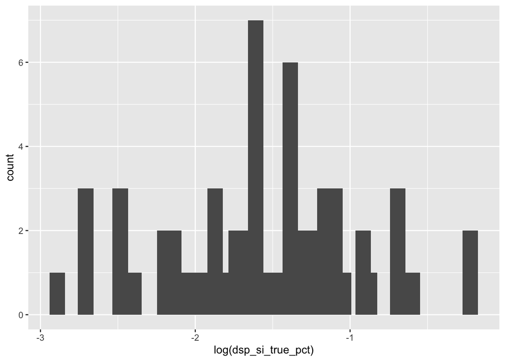

```r
ggplot(data_dsp, aes(x=log(dsp_si_true_pct))) +
   geom_bar(width = 0.1)
```

```r
#I think things need to be changed from 0 to 0. 001
shapiro.test(log(data_dsp$dsp_si_true_pct)) # this comes out as Na but shuyings did not so idk why that's happening.
```

```
##
##  Shapiro-Wilk normality test
##
## data:  log(data_dsp$dsp_si_true_pct)
## W = NaN, p-value = NA
```

LEt’s try a square root transform

The square root transform normalizes it a bit more but it still failed normality test.

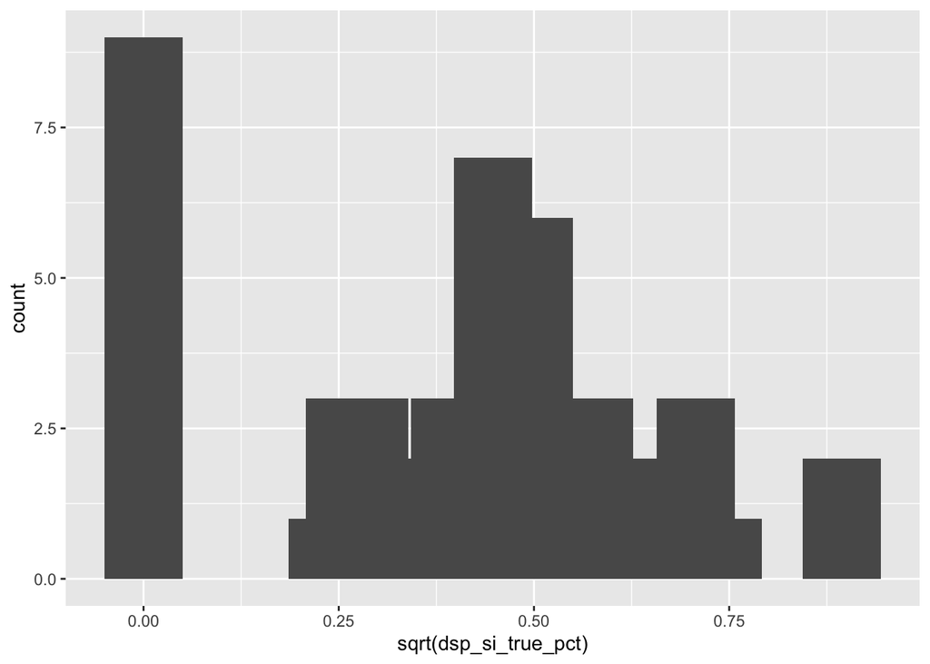

```r
ggplot(data_dsp, aes(x=sqrt(dsp_si_true_pct))) +
   geom_bar(width = 0.1)
```

```r
shapiro.test(sqrt(data_dsp$dsp_si_true_pct)) #
```

```
##
##  Shapiro-Wilk normality test
##
## data:  sqrt(data_dsp$dsp_si_true_pct)
## W = 0.93267, p-value = 0.0006867
```

#### Females DSP Distribution & normality (behav only)

Now here i want to look at the skews for males and females separately. There’s a bit of a skew and it does not pass normality (p-value = 0.001114)

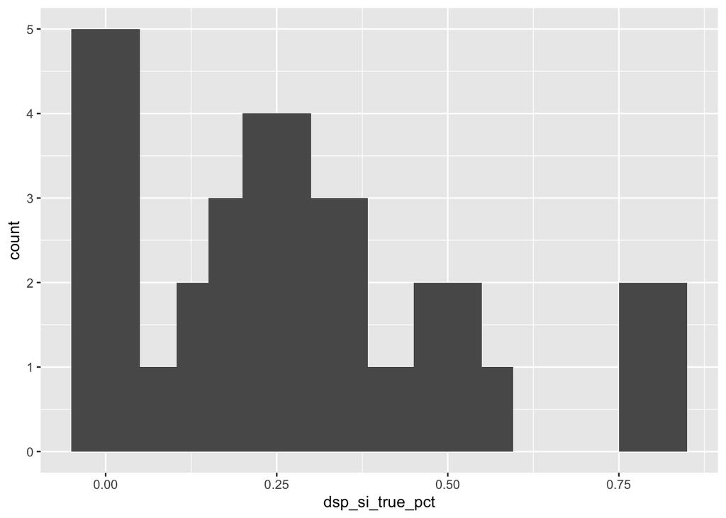

```r
f_data_dsp <- data_dsp %>% filter(sex == "Female") # Women only

ggplot(f_data_dsp, aes(x=dsp_si_true_pct)) +
   geom_bar(width = 0.1)
```

```r
shapiro.test(f_data_dsp$dsp_si_true_pct)
```

```
##
##  Shapiro-Wilk normality test
##
## data:  f_data_dsp$dsp_si_true_pct
## W = 0.90587, p-value = 0.001114
```

```r
df_dsp_norm <- f_data_dsp %>%
  mutate_at(scale, .vars = vars(estradiol_spatial_pg_ml,
                                fsh_spatial_miu_ml,
                                dsp_si_true_pct))
```

LEt’s look at a transformation of all womens data

log transform: again NA for normality test but does appear to fix it a bit

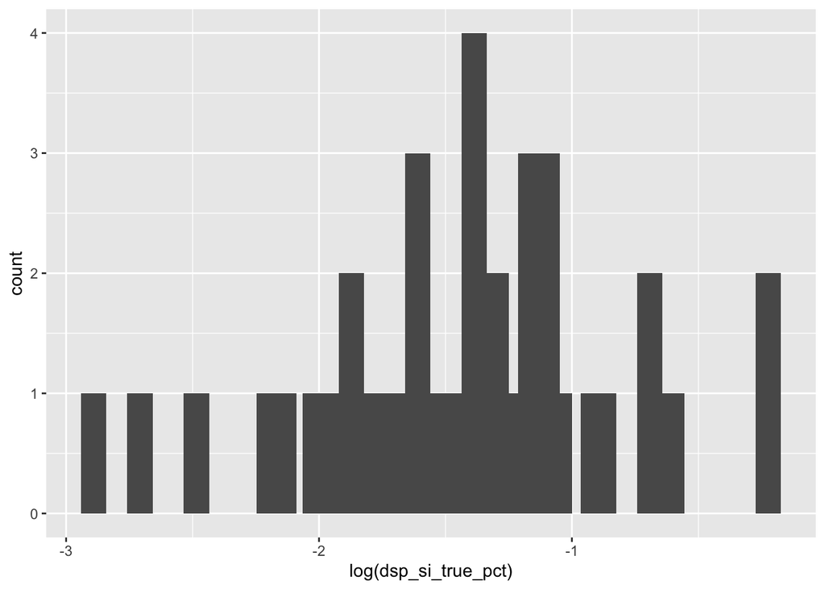

```r
ggplot(f_data_dsp, aes(x=log(dsp_si_true_pct))) +
   geom_bar(width = 0.1)
```

```r
#I think things need to be changed from 0 to 0. 001
shapiro.test(log(f_data_dsp$dsp_si_true_pct)) # this comes out as Na but shuyings did not so idk why that's happening.
```

```
##
##  Shapiro-Wilk normality test
##
## data:  log(f_data_dsp$dsp_si_true_pct)
## W = NaN, p-value = NA
```

Square Transform: again still skewefd and fails normality.

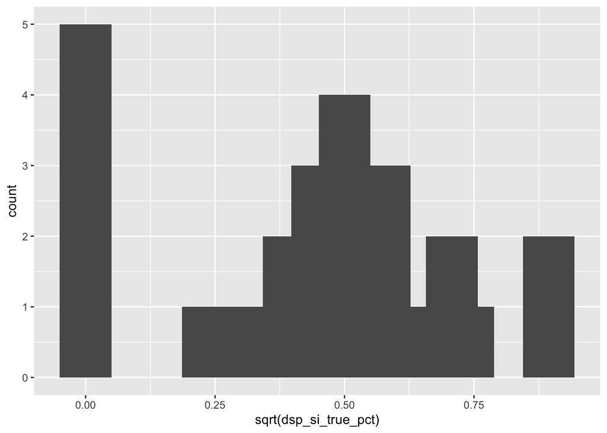

```r
ggplot(f_data_dsp, aes(x=sqrt(dsp_si_true_pct))) +
   geom_bar(width = 0.1)
```

```r
shapiro.test(sqrt(f_data_dsp$dsp_si_true_pct)) #
```

```
##
##  Shapiro-Wilk normality test
##
## data:  sqrt(f_data_dsp$dsp_si_true_pct)
## W = 0.91649, p-value = 0.002527
```

#### Males DSP Distribution & normality (behav only)

Now let’s look at males. Here there is a bit of a skew and it failes normality (p-value = 0.02375)

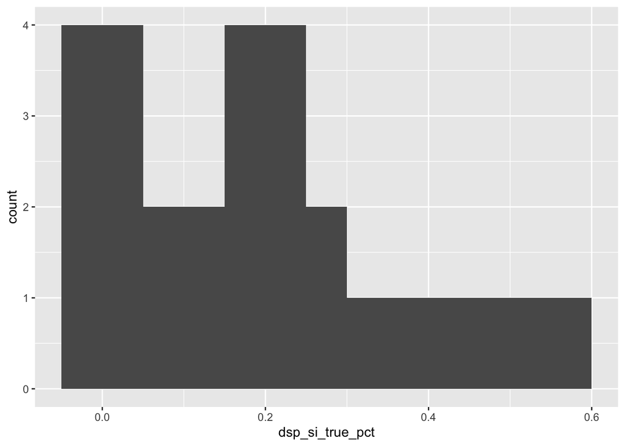

```r
#check visualization and normality of all dsp data not just the scans ones

m_data_dsp<- data_dsp %>% filter(sex=="Male") # Men only


ggplot(m_data_dsp, aes(x=dsp_si_true_pct)) +
   geom_bar(width = 0.1)
```

```r
shapiro.test(m_data_dsp$dsp_si_true_pct)
```

```
##
##  Shapiro-Wilk normality test
##
## data:  m_data_dsp$dsp_si_true_pct
## W = 0.91073, p-value = 0.02375
```

#### Estradiol distribution & normality

Here let’s look at estradial skews for all women who have a dsp score. It does not pass normality 4.352e-07

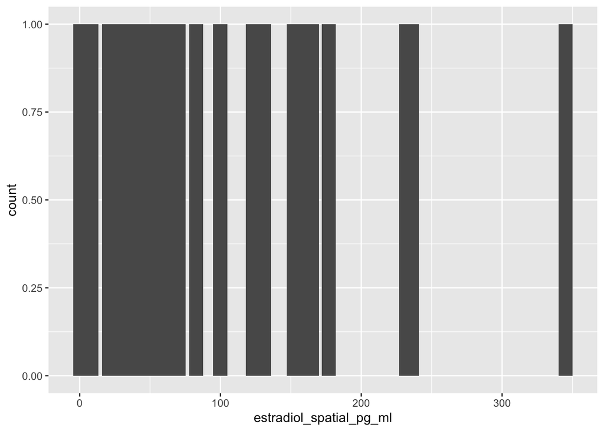

```r
ggplot(f_data_dsp, aes(x=estradiol_spatial_pg_ml)) +
   geom_bar(width = 10)
```

```r
shapiro.test(f_data_dsp$estradiol_spatial_pg_ml)
```

```
##
##  Shapiro-Wilk normality test
##
## data:  f_data_dsp$estradiol_spatial_pg_ml
## W = 0.77401, p-value = 4.352e-07
```

Can we tranform Estradial . This still fails normality but just barely p-value = 0.03153

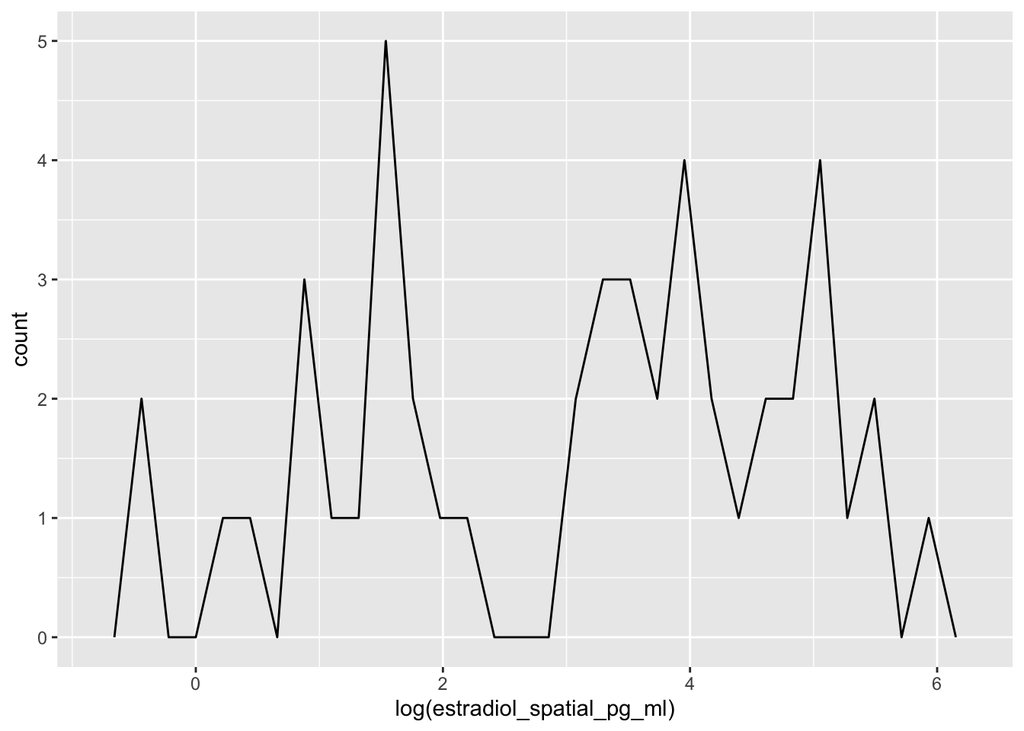

```r
ggplot(f_data_dsp, aes(x=log(estradiol_spatial_pg_ml))) +
   geom_freqpoly(width = 10)
```

```r
shapiro.test(log(f_data_dsp$estradiol_spatial_pg_ml))
```

```
##
##  Shapiro-Wilk normality test
##
## data:  log(f_data_dsp$estradiol_spatial_pg_ml)
## W = 0.94647, p-value = 0.03153
```

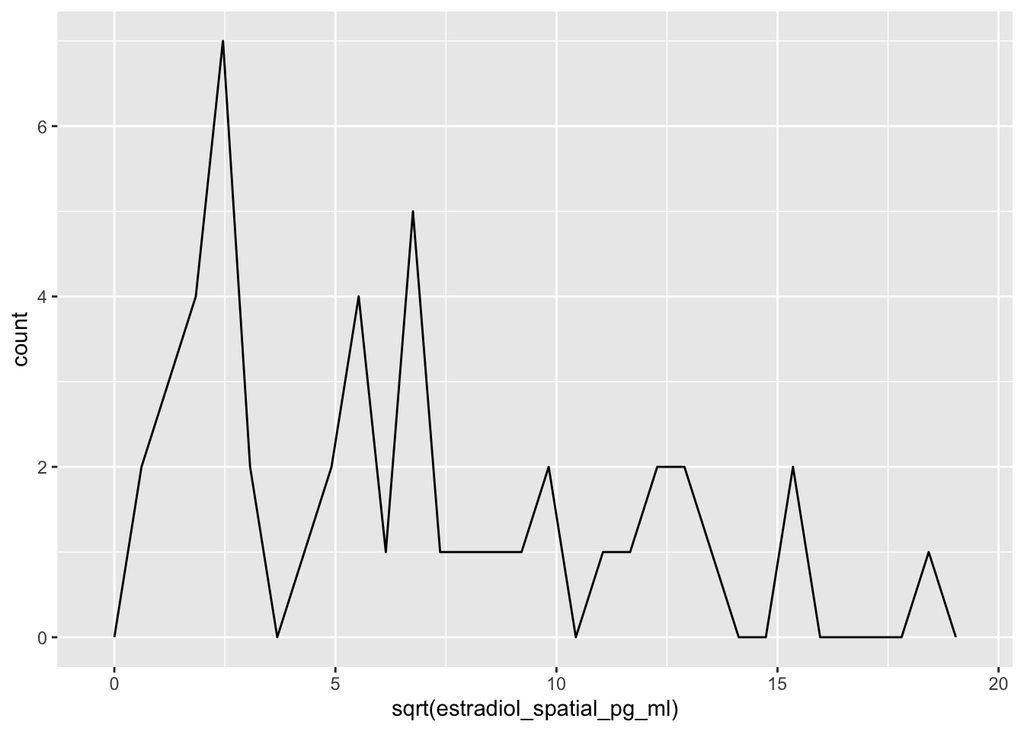

```r
ggplot(f_data_dsp, aes(x=sqrt(estradiol_spatial_pg_ml))) +
   geom_freqpoly(width = 10)
```

```r
shapiro.test(sqrt(f_data_dsp$estradiol_spatial_pg_ml))
```

```
##
##  Shapiro-Wilk normality test
##
## data:  sqrt(f_data_dsp$estradiol_spatial_pg_ml)
## W = 0.91362, p-value = 0.002019
```

#### FSH distribution & normality

FSh also has a skew and fails normality p-value = 0.0008676

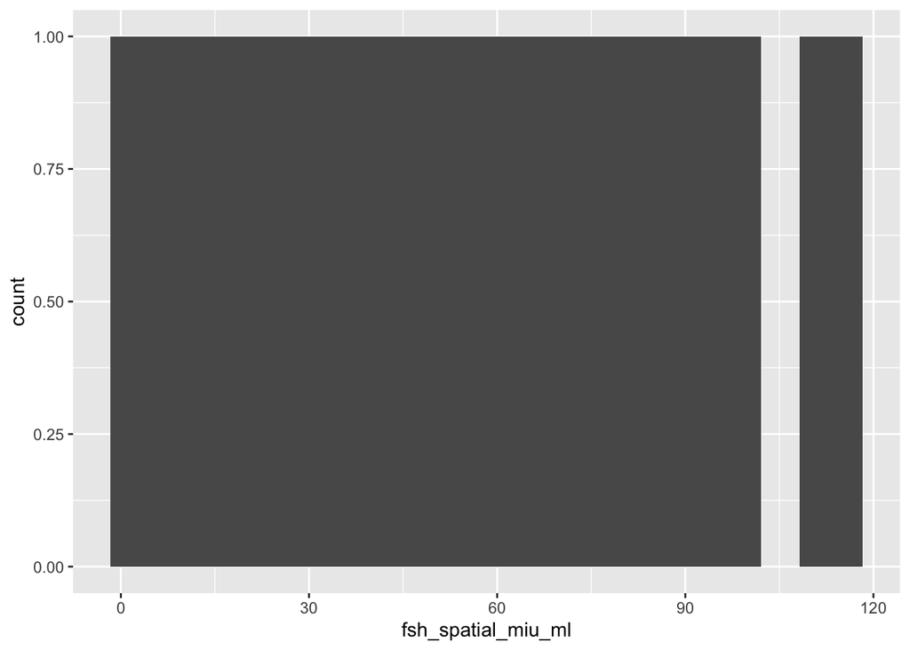

```r
ggplot(f_data_dsp, aes(x=fsh_spatial_miu_ml)) +
   geom_bar(width = 10)
```

```r
shapiro.test(f_data_dsp$fsh_spatial_miu_ml)
```

```
##
##  Shapiro-Wilk normality test
##
## data:  f_data_dsp$fsh_spatial_miu_ml
## W = 0.90068, p-value = 0.0008676
```

Can we tranform FSH . This still fails normality p-value = 0.0008156

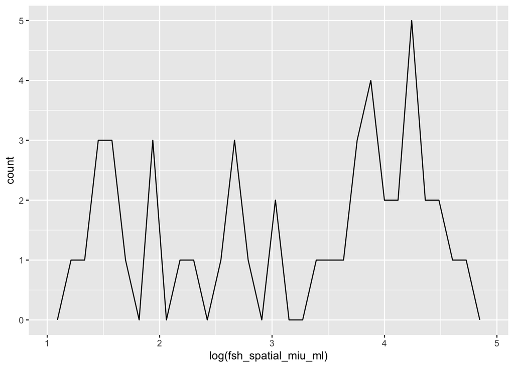

```r
ggplot(f_data_dsp, aes(x=log(fsh_spatial_miu_ml))) +
   geom_freqpoly(width = 10)
```

```r
shapiro.test(log(f_data_dsp$fsh_spatial_miu_ml))
```

```
##
##  Shapiro-Wilk normality test
##
## data:  log(f_data_dsp$fsh_spatial_miu_ml)
## W = 0.89983, p-value = 0.0008156
```

Square root?This still fails normality p-value = 0.003438.

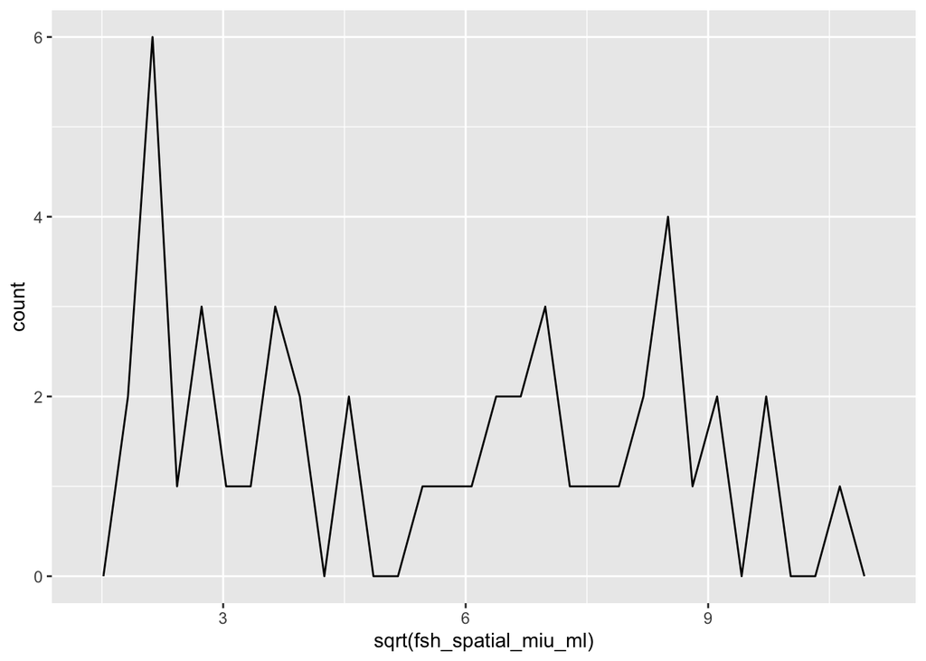

```r
ggplot(f_data_dsp, aes(x=sqrt(fsh_spatial_miu_ml))) +
   geom_freqpoly(width = 10)
```

```r
shapiro.test(sqrt(f_data_dsp$fsh_spatial_miu_ml))
```

```
##
##  Shapiro-Wilk normality test
##
## data:  sqrt(f_data_dsp$fsh_spatial_miu_ml)
## W = 0.91888, p-value = 0.003438
```

No good way to normalize this data so far. I will probably leave it as is.

#### DSP+Scan Distribution

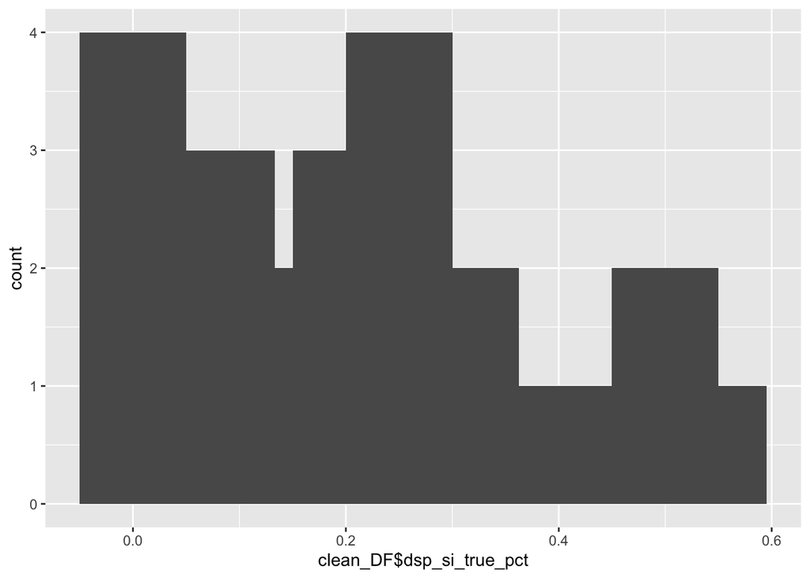

```r
ggplot(clean_DF, aes(x=clean_DF$dsp_si_true_pct)) +
   geom_bar(width = 0.1)
```

```r
shapiro.test(clean_DF$dsp_si_true_pct)
```

```
##
##  Shapiro-Wilk normality test
##
## data:  clean_DF$dsp_si_true_pct
## W = 0.9623, p-value = 0.2254
```

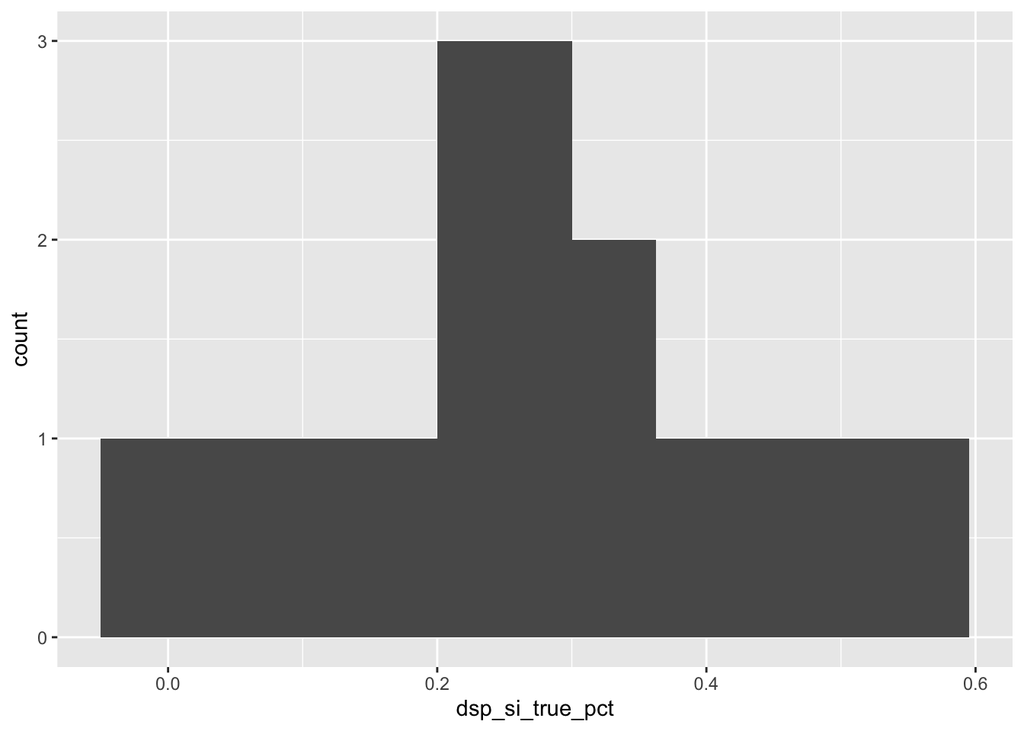

```r
all_women_clean_df <- clean_DF %>% filter(sex=="Female")

ggplot(all_women_clean_df, aes(x=dsp_si_true_pct)) +
   geom_bar(width = 0.1)
```

```r
shapiro.test(all_women_clean_df$dsp_si_true_pct)
```

```
##
##  Shapiro-Wilk normality test
##
## data:  all_women_clean_df$dsp_si_true_pct
## W = 0.98563, p-value = 0.9767
```

So let’s try transforming this

Log transform all subjects. This visually looks much less skewed but also has some infinate numbers so we can check normality. Might need to change the inf to 0?

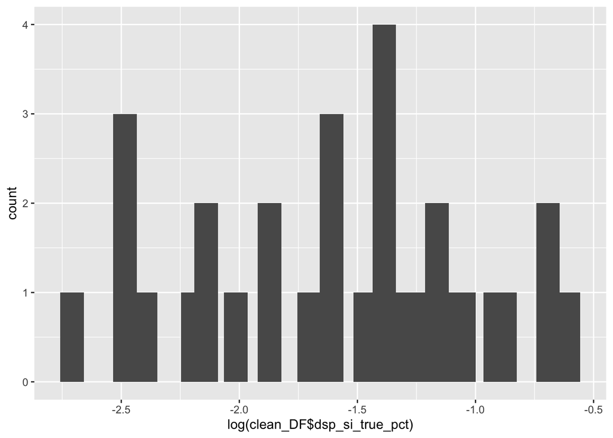

```r
ggplot(clean_DF, aes(x=log(clean_DF$dsp_si_true_pct))) +
   geom_bar(width = 0.1)
```

```r
shapiro.test(log(clean_DF$dsp_si_true_pct))
```

```
##
##  Shapiro-Wilk normality test
##
## data:  log(clean_DF$dsp_si_true_pct)
## W = NaN, p-value = NA
```

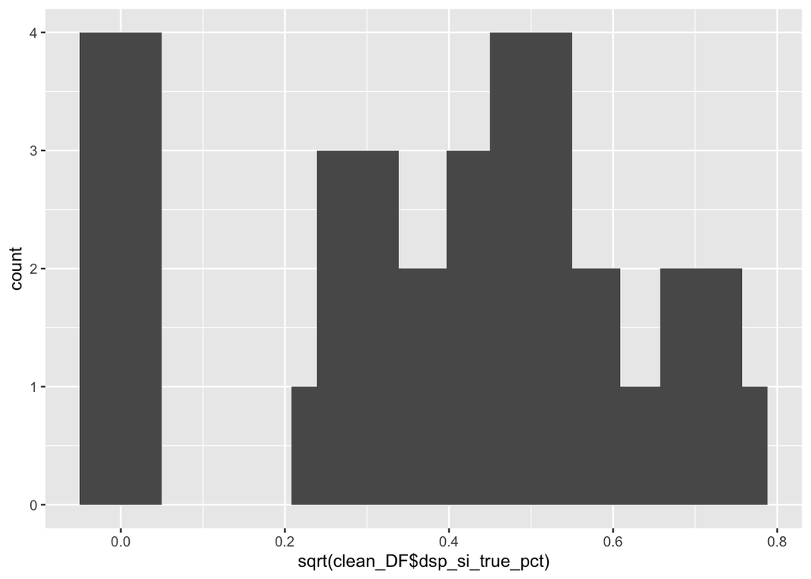

```r
ggplot(clean_DF, aes(x=sqrt(clean_DF$dsp_si_true_pct))) +
   geom_bar(width = 0.1)
```

```r
shapiro.test(sqrt(clean_DF$dsp_si_true_pct))
```

```
##
##  Shapiro-Wilk normality test
##
## data:  sqrt(clean_DF$dsp_si_true_pct)
## W = 0.92012, p-value = 0.009915
```

LEt’s look at the females

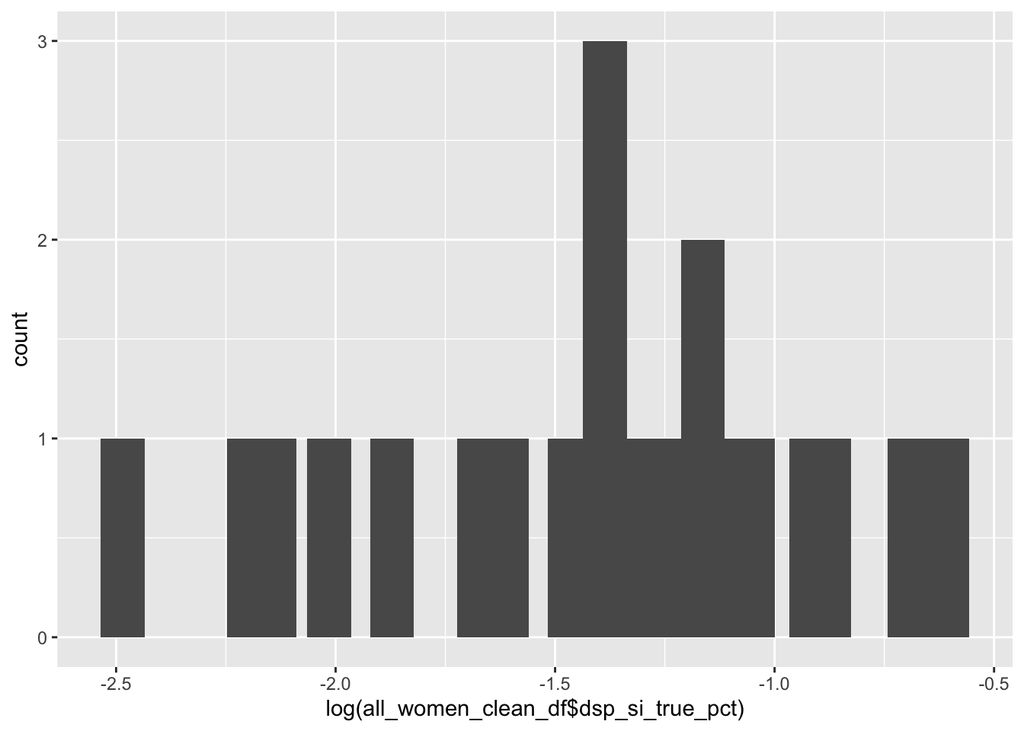

```r
ggplot(all_women_clean_df, aes(x=log(all_women_clean_df$dsp_si_true_pct))) +
   geom_bar(width = 0.1)
```

```r
shapiro.test(log(all_women_clean_df$dsp_si_true_pct))
```

```
##
##  Shapiro-Wilk normality test
##
## data:  log(all_women_clean_df$dsp_si_true_pct)
## W = NaN, p-value = NA
```

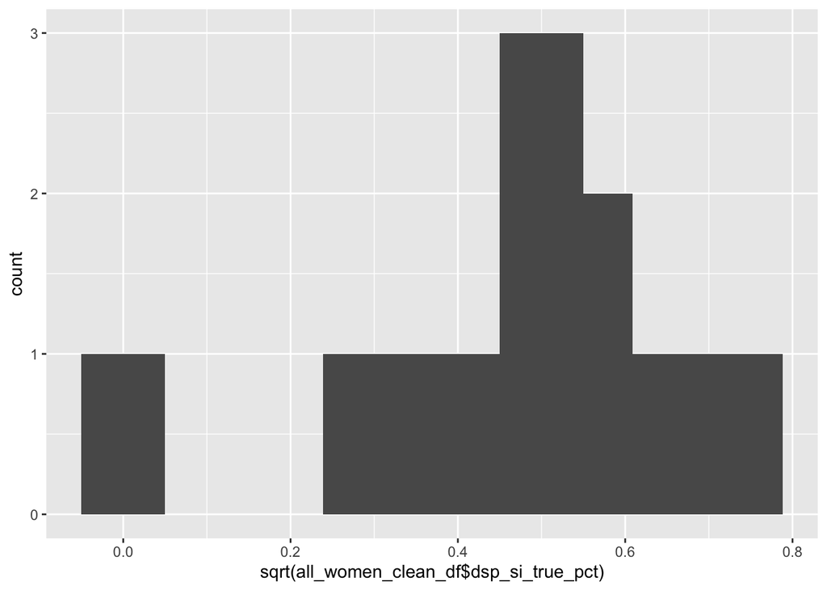

```r
ggplot(all_women_clean_df, aes(x=sqrt(all_women_clean_df$dsp_si_true_pct))) +
   geom_bar(width = 0.1)
```

```r
shapiro.test(sqrt(all_women_clean_df$dsp_si_true_pct))
```

```
##
##  Shapiro-Wilk normality test
##
## data:  sqrt(all_women_clean_df$dsp_si_true_pct)
## W = 0.92188, p-value = 0.07312
```

### Step 3: Prepare the mediation by grabbing our final df. Removing any rows that are NA

```r
mediation_estradiol_DF <-
  clean_DF %>% dplyr::select(
    subject_id,
    sex,
    age_spatial_years,
    repo_status,
    dsp_si_true_pct,
    estradiol_scan_pg_ml,
    estradiol_spatial_pg_ml,
    progesterone_scan_ng_ml,
    testosterone_scan_ng_dl,
    fsh_scan_miu_ml,
    QA_L_fornix,
    QA_R_fornix,
    MD_L_fornix,
    MD_R_fornix,
    MD_Whole_Fornix,
    QA_Whole_Fornix
  ) %>% filter(!is.na(dsp_si_true_pct)) %>% filter(!is.na(estradiol_spatial_pg_ml)) %>% filter(sex == "Female")
```

```r
mediation_test_DF <-
  clean_DF %>% dplyr::select(
    subject_id,
    sex,
    age_spatial_years,
    repo_status,
    dsp_si_true_pct,
    estradiol_scan_pg_ml,
    progesterone_scan_ng_ml,
    testosterone_scan_ng_dl,
    fsh_scan_miu_ml,
    QA_L_fornix,
    QA_R_fornix,
    MD_L_fornix,
    MD_R_fornix
  ) %>% filter(!is.na(dsp_si_true_pct)) %>% filter(!is.na(testosterone_scan_ng_dl)) %>% filter(sex == "Female")
```

```r
mediation_FSH_DF <-
  clean_DF %>% dplyr::select(
    subject_id,
    sex,
    age_spatial_years,
    repo_status,
    dsp_si_true_pct,
    estradiol_scan_pg_ml,
    progesterone_scan_ng_ml,
    testosterone_scan_ng_dl,
    fsh_scan_miu_ml,
    fsh_spatial_miu_ml,
    QA_L_fornix,
    QA_R_fornix,
    MD_L_fornix,
    MD_R_fornix,
    MD_Whole_Fornix,
    QA_Whole_Fornix
  ) %>% filter(!is.na(dsp_si_true_pct)) %>% filter(!is.na(fsh_scan_miu_ml)) %>% filter(sex == "Female")
```

## Can we replicate shuyings findings?

### Estradiol

Below is the code that recreates shuyings results in her dissertation. “For the DSP task, women with higher estradiol levels took more shortcuts, such that higher estradiol levels were positively associated with solution index (rs(45) = 0.42, p = 0.002)”. She used a one-tail spearman correlation because dsp and estradiol fail normality tests. Additionally she removed two subjects due to outliars.

Below are the results without removing outliars our results p=0.001601 N=47

```r
# this one uses spatial hormones
cor.test(f_data_dsp$estradiol_spatial_pg_ml,
         f_data_dsp$dsp_si_true_pct,
         conf.level = 0.95,
         alternative = "greater",
         method = "spearman")
```

```
##
##  Spearman's rank correlation rho
##
## data:  f_data_dsp$estradiol_spatial_pg_ml and f_data_dsp$dsp_si_true_pct
## S = 10012, p-value = 0.001601
## alternative hypothesis: true rho is greater than 0
## sample estimates:
##     rho
## 0.42112
```

```r
#This one uses scan hormones
cor.test(f_data_dsp$estradiol_scan_pg_ml,
         f_data_dsp$dsp_si_true_pct,
         conf.level = 0.95,
         alternative = "greater",
         method = "spearman")
```

```
##
##  Spearman's rank correlation rho
##
## data:  f_data_dsp$estradiol_scan_pg_ml and f_data_dsp$dsp_si_true_pct
## S = 10598, p-value = 0.009179
## alternative hypothesis: true rho is greater than 0
## sample estimates:
##      rho
## 0.346406
```

She also did a partial cor to control for age. here it is still significant even when controlling for age. p-value=0.02876795

```r
pcor.test(f_data_dsp$estradiol_spatial_pg_ml,
          f_data_dsp$dsp_si_true_pct,
          f_data_dsp$age_spatial_years,
          method = "spearman") #p-value=0.02876795
```

```
##    estimate    p.value statistic  n gp   Method
## 1 0.3226078 0.02876795  2.260818 47  1 spearman
```

Here it is if we remove outliars p= 0.0035. REplicates shuyings code and results.

```r
f_data_dsp_outlier_e <- f_data_dsp  %>%  filter(!subject_id %in% c(
    "415", "355"))

cor.test(f_data_dsp_outlier_e$estradiol_spatial_pg_ml,
         f_data_dsp_outlier_e$dsp_si_true_pct,
         alternative = "greater",
         conf.level = 0.95,
         method = "spearman") #p-value:0.003529
```

```
##
##  Spearman's rank correlation rho
##
## data:  f_data_dsp_outlier_e$estradiol_spatial_pg_ml and f_data_dsp_outlier_e$dsp_si_true_pct
## S = 9859.2, p-value = 0.003529
## alternative hypothesis: true rho is greater than 0
## sample estimates:
##      rho
## 0.391972
```

### FSH

Here, its another one tailed correlation test. Pvalue 0.02903

```r
fsh <- f_data_dsp %>% filter(is.na(fsh_spatial_miu_ml) != TRUE)

cor.test(fsh$fsh_spatial_miu_ml,
         fsh$dsp_si_true_pct,
         conf.level = 0.95,
          alternative = "less",
         method = "spearman") # Pvalue 0.02903
```

```
##
##  Spearman's rank correlation rho
##
## data:  fsh$fsh_spatial_miu_ml and fsh$dsp_si_true_pct
## S = 20779, p-value = 0.02903
## alternative hypothesis: true rho is less than 0
## sample estimates:
##        rho
## -0.2814973
```

This is a partial correlation that controls for spatial age and is not significant: Pvalue 0.414744. This replicates some of shuyins code but not what was in the script.

```r
pcor.test(fsh$fsh_spatial_miu_ml,
          fsh$dsp_si_true_pct,
          fsh$age_spatial_years,
          method = "spearman")  # Pvalue 0.414744
```

```
##     estimate  p.value  statistic  n gp   Method
## 1 -0.1246102 0.414744 -0.8235425 46  1 spearman
```

Below is the code that replicated shuyings script for controlling for age.P#0.05638. It’ a correlation with the residuals.

```r
x <- fsh$fsh_spatial_miu_ml
y <- fsh$dsp_si_true_pct
z <- fsh$age_spatial_years
cor.test(lm(x ~ z)$residuals,
         lm(y ~ z)$residuals,
         alternative = "less",
         conf.level = 0.95,
         method = "spearman") #0.05638
```

```
##
##  Spearman's rank correlation rho
##
## data:  lm(x ~ z)$residuals and lm(y ~ z)$residuals
## S = 20058, p-value = 0.05638
## alternative hypothesis: true rho is less than 0
## sample estimates:
##        rho
## -0.2370101
```

## Hormone comparison

### estradiol

Average Scan Estradiol 73.4713043

Average Spatial Estradiol 76.3486957

```r
hormones_df <- all_women_clean_df %>% dplyr::select(c("subject_id","estradiol_scan_pg_ml","estradiol_spatial_pg_ml","progesterone_scan_ng_ml","progesterone_spatial_ng_ml","fsh_scan_miu_ml","fsh_spatial_miu_ml")) #Creating a df that contains just the hormones so i can visualize them side by side.
```

Density plots of the scan and spatial estradiol.

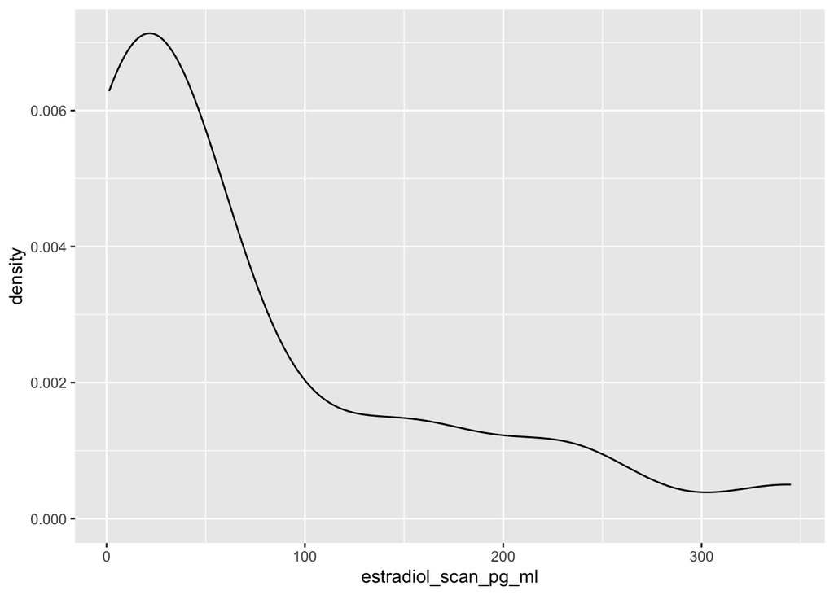

```r
ggplot(data=all_women_clean_df, aes(x=estradiol_scan_pg_ml)) +
  geom_density()
```

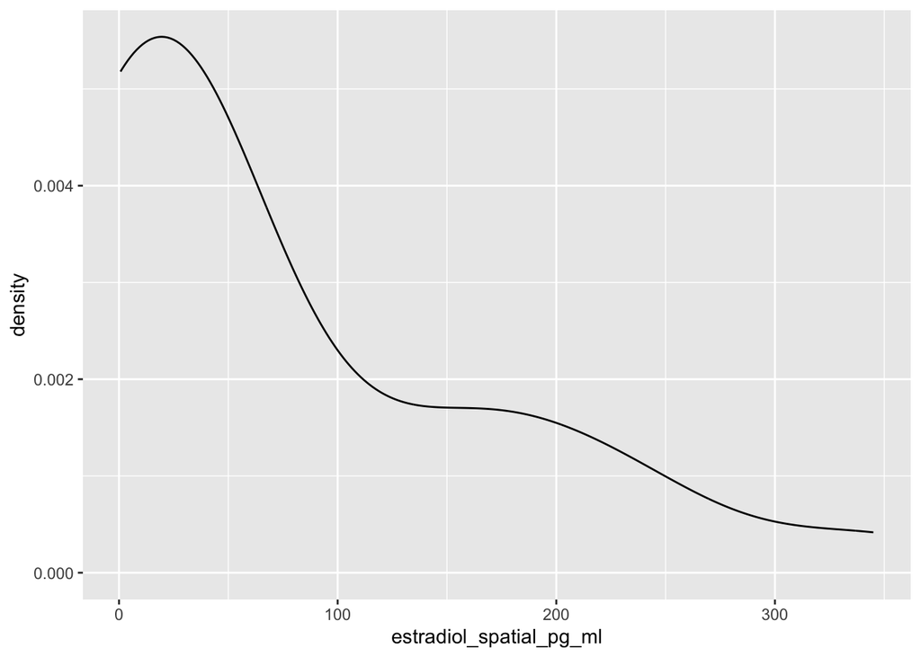

```r
ggplot(data=all_women_clean_df, aes(x=estradiol_spatial_pg_ml)) +
  geom_density()
```

### FSH

Average Scan FSH 38.9952174

Average Spatial FSH 38.9952174

Density plots of the scan and spatial FSH. They’re basically identical tho so i’ll need to check these.

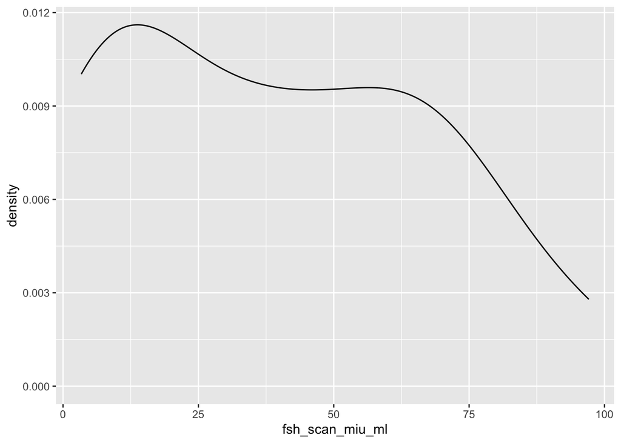

```r
ggplot(data=all_women_clean_df, aes(x=fsh_scan_miu_ml)) +
  geom_density()
```

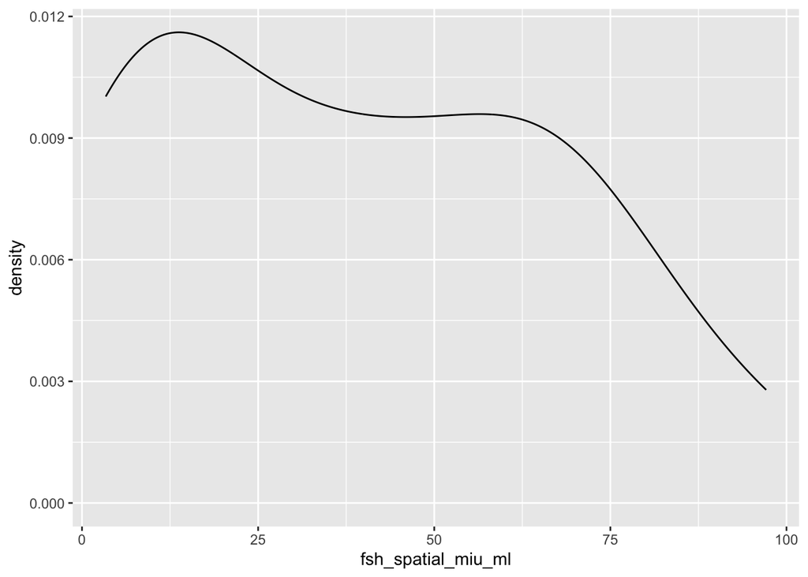

```r
ggplot(data=all_women_clean_df, aes(x=fsh_spatial_miu_ml)) +
  geom_density()
```